# wk12_0513_

Justine

2021/5/13

# inclass

### **題目**

#### **目的** :

1. 研究如何運用R語言來進行文字探勘
2. 應用文字探勘所得到的資料進行分析
3. 透過天龍八部角色之間進行比較分析
4. 利用關聯性分析選取與男女主角相關的重要人物
5. 利用R語言繪製文字雲

#### **解法邏輯思考** :

1.列出所有人名並設定其特殊字串進行探勘 2.利用for迴圈進行矩陣的次數加減 3.接著彙整同一個人物出現次數，因為一個人可能會有不同名稱 4.最後運運直條圖，及相關係數分析去找出想要的結果

#### **函數/結構/語法** :

1. paste()連接兩字的函數
2. gsub()替換函數中的加號
3. matrix()建立一個矩陣的方法
4. apply()取代for迴圈的方法
5. strsplit()切割字串的方法
6. sort()對向量進行從小到大的排序
7. grep()對向量中的具有特定條件的元素進行查詢
8. barplot()創建條形圖
9. cor()計算相關係數
10. wordcloud()繪製詞雲圖

#### **逐行or區段說明** :

將所有人物名稱以c1代替，k為c1之長度，也就是人名總數為45，c3為將前九個人名以CA01到CA09命名，第十位到第四十五位以CA10到CA45命名，c2為將c3的所有字串加上“~”。

```r
rm(list=ls())
#定義主要人物之人名
c1 <- c("喬峰","喬幫主","蕭峰","蕭大王","蕭大俠","虛竹","段譽","阿朱","阮姑娘","阿紫",
        "語嫣","王姑娘","婉清","婉兒","清兒","鍾靈","靈兒","靈妹","段正明","段皇爺",
        "段正淳","段王爺","刀白鳳","秦紅棉","甘寶寶","阮星竹","李青蘿","康敏","慕容復","慕容博",
        "鳩摩智","蕭遠山","無崖子","天山童姥","李秋水","蘇星河","丁春秋","段延慶","葉二娘","岳老三",
        "岳老二","雲中鶴","游坦之","王夫人","馬夫人");
k <- length(c1);
#將人名替代為特殊的英文字串
c3 <- c(paste("CA0",1:9, sep=""), paste("CA",10:k, sep=""))
c2 <-paste( c3,"~",sep="")
```

```r
num.hei <- 50   #定義回數  共50回
y <- matrix(0, nrow=k, ncol=num.hei)
row.names(y)<- c1; colnames(y)<-paste(1:num.hei,"回"); str(y)
```

```
##  num [1:45, 1:50] 0 0 0 0 0 0 0 0 0 0 ...
##  - attr(*, "dimnames")=List of 2
##   ..$ : chr [1:45] "喬峰" "喬幫主" "蕭峰" "蕭大王" ...
##   ..$ : chr [1:50] "1 回" "2 回" "3 回" "4 回" ...
```

```r
for (j in 1:num.hei){
  file.use <- paste(paste("long/dragon",j, sep=""),".txt",sep="")
  x <- paste( scan(file=file.use,what=character()),collapse=" ");x

  for (i in 1:k) {
    x <- gsub(c1[i],c2[i],x, fixed=TRUE);x
  }
  x
  x1 <- strsplit(x,"~"); x1

  for (i in 1:k){  y[i,j] <- length(grep(c3[i],x1[[1]]))}
}
#1 人物與回數矩陣
y
```

```
##          1 回 2 回 3 回 4 回 5 回 6 回 7 回 8 回 9 回 10 回 11 回 12 回 13 回
## 喬峰        0    0    0    0    0    0    0    0    1     0     0     1     0
## 喬幫主      0    0    0    0    0    0    0    0    0     0     0     0     0
## 蕭峰        0    0    0    0    0    0    0    0    0     0     0     0     0
## 蕭大王      0    0    0    0    0    0    0    0    0     0     0     0     0
## 蕭大俠      0    0    0    0    0    0    0    0    0     0     0     0     0
## 虛竹        0    0    0    0    0    0    0    0    0     0     0     0     0
## 段譽      147  122  226  212  101  186   69   62   88   106   155   194    50
## 阿朱        0    0    0    0    0    0    0    0    0     0    89    62    81
## 阮姑娘      0    0    0    0    0    0    0    0    0     0     0     0     0
## 阿紫        0    0    0    0    0    0    0    0    0     0     0     0     0
## 語嫣        0    0    0    0    0    0    0    0    0     0     0    65    94
## 王姑娘      0    0    0    0    0    0    0    0    0     0     0     7    22
## 婉清        0    0   42  190   45  123  171   12   25     1     4     0     0
## 婉兒        0    0    0    0    0    0    7    0    1     0     0     0     0
## 清兒        0    0    0    0    0    0    0    0    0     0     0     0     0
## 鍾靈      117   17   51    7    1    0    0   26   70     0     0     1     0
## 靈兒        1    1    0    0    0    0    0    5    3     0     0     0     0
## 靈妹        0    0    0    0    0    0    0    0    2     0     0     0     0
## 段正明      0    0    0    0    0    2    4   12    2     0     0     1     0
## 段皇爺      0    0    0    0    0    0    0    0    2     0     0     0     0
## 段正淳      0    4    0    0    0   25  116   54  113     2     0     1     0
## 段王爺      0    0    0    0    0    0    1    0    3     0     0     0     0
## 刀白鳳      0    0    0    0    0    0   21   30   15     3     0     0     0
## 秦紅棉      0    0    0    0    0    4   42   25    2     1     0     0     0
## 甘寶寶      0    2    0    4    0    0    9    2   21     0     0     0     0
## 阮星竹      0    0    0    0    0    0    0    0    0     0     0     0     0
## 李青蘿      0    0    0    0    0    0    0    0    0     0     0     0     0
## 康敏        0    0    0    0    0    0    0    0    0     0     0     0     0
## 慕容復      0    0    0    0    0    0    0    0    0     0     0     4     3
## 慕容博      0    0    0    0    0    0    0    0   12     3     4     0     3
## 鳩摩智      0    0    0    0    0    0    0    0    0   106   154     1     0
## 蕭遠山      0    0    0    0    0    0    0    0    0     0     0     0     0
## 無崖子      0    0    0    0    0    0    0    0    0     0     0     0     0
## 天山童姥    3    0    2    0    1    0    0    0    0     0     0     0     0
## 李秋水      0    0    0    0    0    0    0    0    0     0     0     0     0
## 蘇星河      0    0    0    0    0    0    0    0    0     0     0     0     0
## 丁春秋      0    0    0    0    0    0    0    0    0     4     0     0     0
## 段延慶      0    0    0    0    0    0    0    0    5     1     0     0     0
## 葉二娘      0    0    0   35   55    4    7   11   20     2     0     0     0
```

[output cut: 175 more lines]

```
## 鳩摩智       2     3     0     1
## 蕭遠山       0     0     0     1
## 無崖子       0     0     0     0
## 天山童姥     0     0     0     1
## 李秋水       0     0     0     0
## 蘇星河       0     0     0     0
## 丁春秋       0     0     1     0
## 段延慶      32   118     0     0
## 葉二娘       0     1     0     0
## 岳老三       0     2     0     0
## 岳老二       0     0     0     0
## 雲中鶴       0     8     0     0
## 游坦之       0     0     6    13
## 王夫人      76    73     0     0
## 馬夫人       0     0     0     0
```

```r
#彙整相同人物使用不同的名稱
copy.y <- y  #先做一份拷貝，再進行匯整整理
copy.y[1,]<-copy.y[1,]+copy.y[2,]+copy.y[3,]+copy.y[4,]+copy.y[5,] #彙整喬峰
copy.y[8,] <-copy.y[8,] + copy.y[9,]#彙整阿朱

copy.y[11,] <- copy.y[11,]+copy.y[12,] #彙整王語嫣
copy.y[13,] <- copy.y[13,]+copy.y[14,]+copy.y[15,] #彙整木婉清
copy.y[16,] <- copy.y[16,]+copy.y[17,]+copy.y[18,] #彙整鍾靈
copy.y[19,] <- copy.y[19,]+copy.y[20,] #彙整段正明
copy.y[21,] <- copy.y[21,]+copy.y[22,] #彙整段正淳
copy.y[40,] <- copy.y[40,]+copy.y[41,] #彙整岳老三
copy.y[27,] <- copy.y[27,]+copy.y[44,] #彙整李青蘿
copy.y[28,] <- copy.y[28,]+copy.y[45,] #彙整康敏
y22<-copy.y[-c(2:5,9,12,14,15,17,18,20,22,41,44,45),]
y22    #形成了統一人名後的完整矩陣
```

```
##          1 回 2 回 3 回 4 回 5 回 6 回 7 回 8 回 9 回 10 回 11 回 12 回 13 回
## 喬峰        0    0    0    0    0    0    0    0    1     0     0     1     0
## 虛竹        0    0    0    0    0    0    0    0    0     0     0     0     0
## 段譽      147  122  226  212  101  186   69   62   88   106   155   194    50
## 阿朱        0    0    0    0    0    0    0    0    0     0    89    62    81
## 阿紫        0    0    0    0    0    0    0    0    0     0     0     0     0
## 語嫣        0    0    0    0    0    0    0    0    0     0     0    72   116
## 婉清        0    0   42  190   45  123  178   12   26     1     4     0     0
## 鍾靈      118   18   51    7    1    0    0   31   75     0     0     1     0
## 段正明      0    0    0    0    0    2    4   12    4     0     0     1     0
## 段正淳      0    4    0    0    0   25  117   54  116     2     0     1     0
## 刀白鳳      0    0    0    0    0    0   21   30   15     3     0     0     0
## 秦紅棉      0    0    0    0    0    4   42   25    2     1     0     0     0
## 甘寶寶      0    2    0    4    0    0    9    2   21     0     0     0     0
## 阮星竹      0    0    0    0    0    0    0    0    0     0     0     0     0
## 李青蘿      0    0    0    0    0    0    0    0    0     0     0    87     1
## 康敏        0    0    0    0    0    0    0    0    0     0     0     0     0
## 慕容復      0    0    0    0    0    0    0    0    0     0     0     4     3
## 慕容博      0    0    0    0    0    0    0    0   12     3     4     0     3
## 鳩摩智      0    0    0    0    0    0    0    0    0   106   154     1     0
## 蕭遠山      0    0    0    0    0    0    0    0    0     0     0     0     0
## 無崖子      0    0    0    0    0    0    0    0    0     0     0     0     0
## 天山童姥    3    0    2    0    1    0    0    0    0     0     0     0     0
## 李秋水      0    0    0    0    0    0    0    0    0     0     0     0     0
## 蘇星河      0    0    0    0    0    0    0    0    0     0     0     0     0
## 丁春秋      0    0    0    0    0    0    0    0    0     4     0     0     0
## 段延慶      0    0    0    0    0    0    0    0    5     1     0     0     0
## 葉二娘      0    0    0   35   55    4    7   11   20     2     0     0     0
## 岳老三      0   10    0   10    2   13    0    2   12     0     0     0     0
## 雲中鶴      0    0    0    9   37   34    3   15   48     2     0     0     0
## 游坦之      0    0    0    0    0    0    0    0    0     0     0     0     0
##          14 回 15 回 16 回 17 回 18 回 19 回 20 回 21 回 22 回 23 回 24 回
## 喬峰       100   134   110     7   279   223   121   267   152   142   140
## 虛竹         0     0     0     0     0     0     0     0     0     0     0
## 段譽        90    17    26   261    86     0     0     9     0     1     0
## 阿朱        19    16     9     5   129    57    85   183    55   124     6
## 阿紫         0     0     0     0     0     0     0     0    39    63    34
## 語嫣        38    19    24   176    29     0     0     0     0     0     0
## 婉清         2     0     0     0     2     0     0     0     1    13     0
## 鍾靈         1     0     0     0     0     0     0     0     0     0     0
```

[output cut: 100 more lines]

```
## 康敏         0     0     0     0
## 慕容復      50   127     0     7
## 慕容博       0     1     0     0
## 鳩摩智       2     3     0     1
## 蕭遠山       0     0     0     1
## 無崖子       0     0     0     0
## 天山童姥     0     0     0     1
## 李秋水       0     0     0     0
## 蘇星河       0     0     0     0
## 丁春秋       0     0     1     0
## 段延慶      32   118     0     0
## 葉二娘       0     1     0     0
## 岳老三       0     2     0     0
## 雲中鶴       0     8     0     0
## 游坦之       0     0     6    13
```

```r
#2  人物出現總次數列表
y.row.sum <- apply(y22,1,sum)
#前十名人物與對應的的長條圖
y.row.sum.first.10 <- sort(y.row.sum,decreasing = TRUE)[1:10]
y.row.sum.first.10
```

```
##   段譽   喬峰   虛竹   阿紫   語嫣   阿朱 慕容復 段正淳   婉清 鳩摩智
##   3371   3103   1634   1132   1071    994    912    766    745    563
```

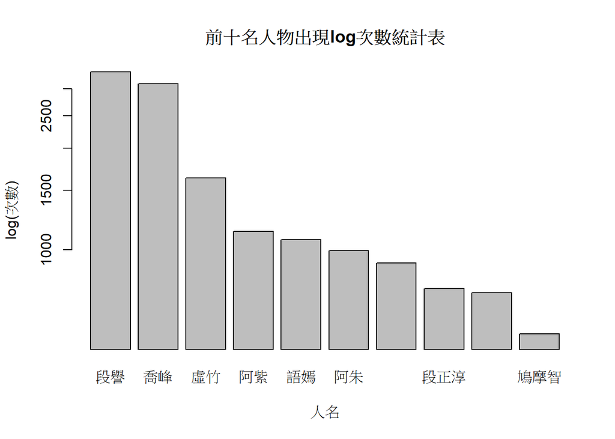

```r
barplot(y.row.sum.first.10,names.arg=names(y.row.sum.first.10),log="y",
        xlab="人名", ylab="log(次數)",main="前十名人物出現log次數統計表")
```

```r
#人物相關係數矩陣
cor(t(y22))
```

```
##                  喬峰         虛竹        段譽        阿朱         阿紫
## 喬峰      1.000000000 -0.292910504 -0.40714060  0.53514198  0.398412133
## 虛竹     -0.292910504  1.000000000 -0.27937676 -0.25369790 -0.143897782
## 段譽     -0.407140604 -0.279376758  1.00000000 -0.13630659 -0.295068029
## 阿朱      0.535141980 -0.253697899 -0.13630659  1.00000000 -0.041606102
## 阿紫      0.398412133 -0.143897782 -0.29506803 -0.04160610  1.000000000
## 語嫣     -0.213336680 -0.094651897  0.44846803 -0.01245479 -0.175384674
## 婉清     -0.224372191 -0.166700403  0.40555158 -0.15439103 -0.137636503
## 鍾靈     -0.186959175 -0.105008440  0.38063123 -0.17223987  0.009572669
## 段正明   -0.190055239 -0.175586865  0.11483210 -0.14179662 -0.129047915
## 段正淳   -0.006395203 -0.204849288 -0.09028872  0.03937781 -0.040942219
## 刀白鳳   -0.219314853 -0.152961437  0.04808019 -0.14615682 -0.146181996
## 秦紅棉   -0.085097303 -0.170604113 -0.04345128  0.04679342 -0.050953559
## 甘寶寶   -0.200678503 -0.154278229  0.13168868 -0.12219397 -0.135026979
## 阮星竹    0.157269405 -0.128303724 -0.16627090  0.33906272  0.135907228
## 李青蘿   -0.188302262 -0.131920398  0.24666565  0.02455522 -0.123436168
## 康敏      0.309721279 -0.123146713 -0.20947855  0.22627472  0.006163319
## 慕容復   -0.211143383 -0.028944264  0.09602408 -0.19430998 -0.080857046
## 慕容博   -0.027912081 -0.049574409 -0.06592008 -0.08491395 -0.097508922
## 鳩摩智   -0.224561351  0.028231275  0.16306521  0.04978743 -0.168068713
## 蕭遠山    0.016793506 -0.002904962 -0.09495839 -0.08581883 -0.083731005
## 無崖子   -0.192131663  0.705409456 -0.22121050 -0.12801227 -0.124509589
## 天山童姥 -0.183328719  0.194470291  0.08760658 -0.14234273 -0.094222284
## 李秋水   -0.151478765  0.514315166 -0.18010600 -0.10262594 -0.098947934
## 蘇星河   -0.158390706  0.390247072 -0.15347753 -0.11220376 -0.038531841
## 丁春秋   -0.168489931  0.194384682 -0.22278210 -0.18930558  0.074101241
## 段延慶   -0.067750432 -0.050700089  0.02314751 -0.04117150 -0.073726935
## 葉二娘   -0.172015106 -0.053170226  0.15128693 -0.14370923 -0.158228285
## 岳老三   -0.171836272 -0.158806757  0.43449768 -0.14105825 -0.095773931
## 雲中鶴   -0.170608874 -0.195863234  0.22277205 -0.14396776 -0.180207908
## 游坦之   -0.027517546 -0.079401287 -0.14432669 -0.12396062  0.521359746
##                 語嫣        婉清         鍾靈      段正明       段正淳
## 喬峰     -0.21333668 -0.22437219 -0.186959175 -0.19005524 -0.006395203
## 虛竹     -0.09465190 -0.16670040 -0.105008440 -0.17558687 -0.204849288
## 段譽      0.44846803  0.40555158  0.380631231  0.11483210 -0.090288719
## 阿朱     -0.01245479 -0.15439103 -0.172239871 -0.14179662  0.039377805
## 阿紫     -0.17538467 -0.13763650  0.009572669 -0.12904791 -0.040942219
## 語嫣      1.00000000 -0.13884669 -0.085283425 -0.07524092 -0.205811835
## 婉清     -0.13884669  1.00000000  0.060958722  0.12197608  0.273242167
## 鍾靈     -0.08528343  0.06095872  1.000000000  0.12981460  0.111296571
```

[output cut: 131 more lines]

```
## 康敏     -0.06924504 -0.081409595 -0.10735295 -0.06814038 -0.07010340
## 慕容復    0.39641164 -0.007816064  0.09120274 -0.04300403  0.06597769
## 慕容博   -0.04075193  0.110960491  0.02470480  0.03126534 -0.03498364
## 鳩摩智   -0.04044961 -0.089697518 -0.01205078 -0.06143920 -0.09000203
## 蕭遠山   -0.05118762  0.179489259 -0.04893912 -0.07522391 -0.02905345
## 無崖子   -0.07034148 -0.094817172 -0.12177863 -0.11012824 -0.07660633
## 天山童姥 -0.07991464 -0.075052179 -0.10382142 -0.09850222 -0.06580957
## 李秋水   -0.06124713 -0.075737403 -0.09600840 -0.08819686 -0.06314147
## 蘇星河    0.09507393 -0.065666877 -0.08569502 -0.08390269 -0.03481844
## 丁春秋   -0.01553083 -0.011968903 -0.07352436 -0.16372750  0.34348596
## 段延慶    1.00000000 -0.016698233  0.02842833  0.07021602 -0.08098612
## 葉二娘   -0.01669823  1.000000000  0.29698449  0.51630104 -0.09120818
## 岳老三    0.02842833  0.296984489  1.00000000  0.64989684 -0.01601081
## 雲中鶴    0.07021602  0.516301036  0.64989684  1.00000000 -0.11492180
## 游坦之   -0.08098612 -0.091208176 -0.01601081 -0.11492180  1.00000000
```

```r
#3  人物有出現在哪一回矩陣
y2 <- 1*(y22 & TRUE)
y2.times<- apply(y2,1, sum)
y2.times
```

```
##     喬峰     虛竹     段譽     阿朱     阿紫     語嫣     婉清     鍾靈
##       33       20       41       29       20       25       20       15
##   段正明   段正淳   刀白鳳   秦紅棉   甘寶寶   阮星竹   李青蘿     康敏
##       11       22        6       10        9       10        5       10
##   慕容復   慕容博   鳩摩智   蕭遠山   無崖子 天山童姥   李秋水   蘇星河
##       26       10       17        6        5       11        7       10
##   丁春秋   段延慶   葉二娘   岳老三   雲中鶴   游坦之
##       19       18       18       15       18       16
```

```r
#  三大男主角與慕容復比較分析--出現次數
y.row.sum[c("段譽","喬峰","虛竹","慕容復")]
```

```
##   段譽   喬峰   虛竹 慕容復
##   3371   3103   1634    912
```

```r
#  三大男主角與慕容復比較分析--回數出現數
y2.times[c("段譽","喬峰","虛竹","慕容復")]
```

```
##   段譽   喬峰   虛竹 慕容復
##     41     33     20     26
```

```r
#  女主角比較分析--出現次數
y.row.sum[c("語嫣","阿朱","阿紫","婉清")]
```

```
## 語嫣 阿朱 阿紫 婉清
## 1071  994 1132  745
```

```r
#  女主角比較分析--回數出現數
y2.times[c("語嫣","阿朱","阿紫","婉清")]
```

```
## 語嫣 阿朱 阿紫 婉清
##   25   29   20   20
```

```r
#  四大惡人比較分析--出現次數
y.row.sum[c("段延慶","葉二娘","岳老三","雲中鶴")]
```

```
## 段延慶 葉二娘 岳老三 雲中鶴
##    298    211     83    215
```

```r
#  四大惡人比較分析--回數出現數
y2.times[c("段延慶","葉二娘","岳老三","雲中鶴")]
```

```
## 段延慶 葉二娘 岳老三 雲中鶴
##     18     18     15     18
```

```r
y2.times.10<- sort(y2.times, decreasing = TRUE)[1:10]
#出現再50回中次數最多的前十名人物及長條圖
y2.times.10
```

```
##   段譽   喬峰   阿朱 慕容復   語嫣 段正淳   虛竹   阿紫   婉清 丁春秋
##     41     33     29     26     25     22     20     20     20     19
```

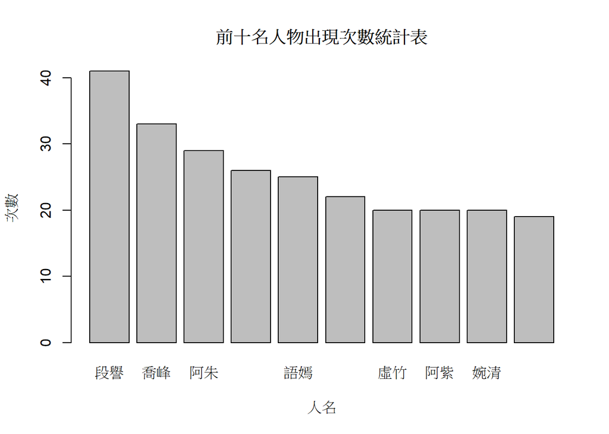

```r
barplot(y2.times.10,names.arg=names(y2.times.10),
        xlab="人名", ylab="次數",main="前十名人物出現次數統計表")
```

```r
#段正淳羅曼史的相關分析
wife.vec<-c1 <- c("秦紅棉","甘寶寶","阮星竹","李青蘿","康敏")
#段正淳羅曼史的總出現次數 與 長條圖
apply(y22[wife.vec, ],1,sum)
```

```
## 秦紅棉 甘寶寶 阮星竹 李青蘿   康敏
##    126     52    115    238    297
```

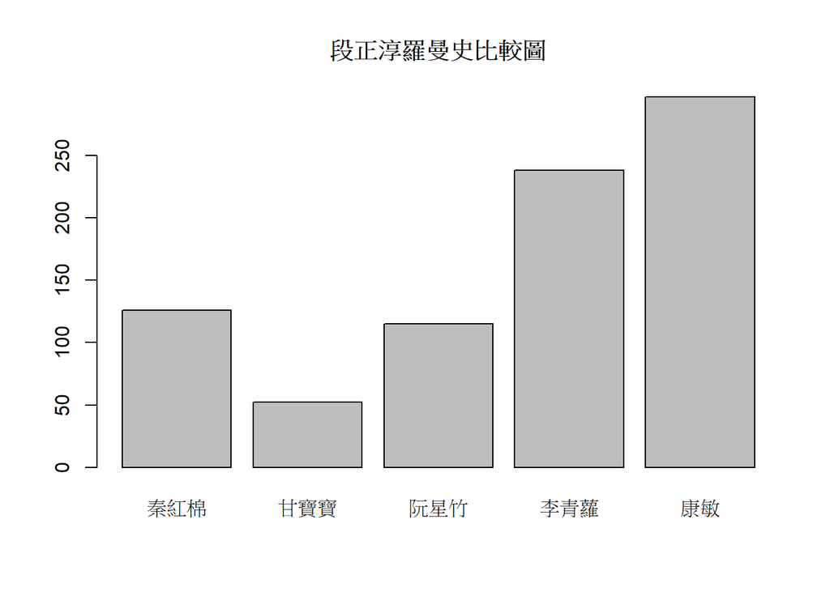

```r
barplot(apply(y22[wife.vec, ],1,sum),main="段正淳羅曼史比較圖")
```

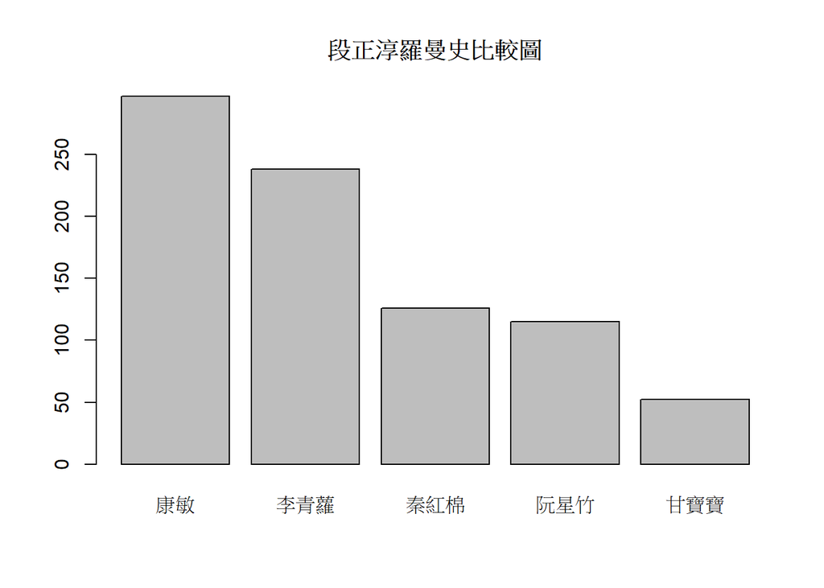

```r
#以出現次數多寡繪製的條圖
barplot(sort(apply(y22[wife.vec, ],1,sum),decreasing=TRUE),main="段正淳羅曼史比較圖")
```

```r
#段正淳情婦的相關係數
cor(t(y22[c("段正淳",wife.vec), ]))
```

```
##           段正淳     秦紅棉      甘寶寶     阮星竹      李青蘿        康敏
## 段正淳 1.0000000 0.70296027  0.66977413 0.48760844  0.10773444  0.40644591
## 秦紅棉 0.7029603 1.00000000  0.36986527 0.44289251  0.08027067  0.12699395
## 甘寶寶 0.6697741 0.36986527  1.00000000 0.08225059  0.19210737 -0.06741379
## 阮星竹 0.4876084 0.44289251  0.08225059 1.00000000  0.11584928  0.17831273
## 李青蘿 0.1077344 0.08027067  0.19210737 0.11584928  1.00000000 -0.06055856
## 康敏   0.4064459 0.12699395 -0.06741379 0.17831273 -0.06055856  1.00000000
```

```r
#結果分析-男女主角之間的相關關係
cor(t(y22[c("喬峰","虛竹","段譽","阿朱","阿紫","語嫣","婉清"), ]))
```

```
##            喬峰       虛竹       段譽        阿朱       阿紫        語嫣
## 喬峰  1.0000000 -0.2929105 -0.4071406  0.53514198  0.3984121 -0.21333668
## 虛竹 -0.2929105  1.0000000 -0.2793768 -0.25369790 -0.1438978 -0.09465190
## 段譽 -0.4071406 -0.2793768  1.0000000 -0.13630659 -0.2950680  0.44846803
## 阿朱  0.5351420 -0.2536979 -0.1363066  1.00000000 -0.0416061 -0.01245479
## 阿紫  0.3984121 -0.1438978 -0.2950680 -0.04160610  1.0000000 -0.17538467
## 語嫣 -0.2133367 -0.0946519  0.4484680 -0.01245479 -0.1753847  1.00000000
## 婉清 -0.2243722 -0.1667004  0.4055516 -0.15439103 -0.1376365 -0.13884669
##            婉清
## 喬峰 -0.2243722
## 虛竹 -0.1667004
## 段譽  0.4055516
## 阿朱 -0.1543910
## 阿紫 -0.1376365
## 語嫣 -0.1388467
## 婉清  1.0000000
```

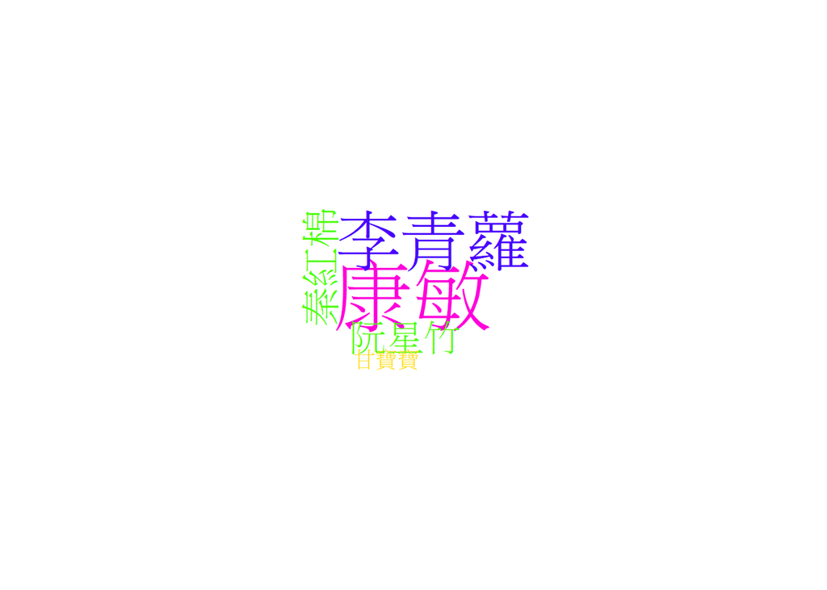

```r
#install.packages("wordcloud")
library(wordcloud)
wordcloud(wife.vec,apply(y22[wife.vec, ],1,sum),random.order=FALSE,rot.per=.5,
          colors= rainbow(7))
```

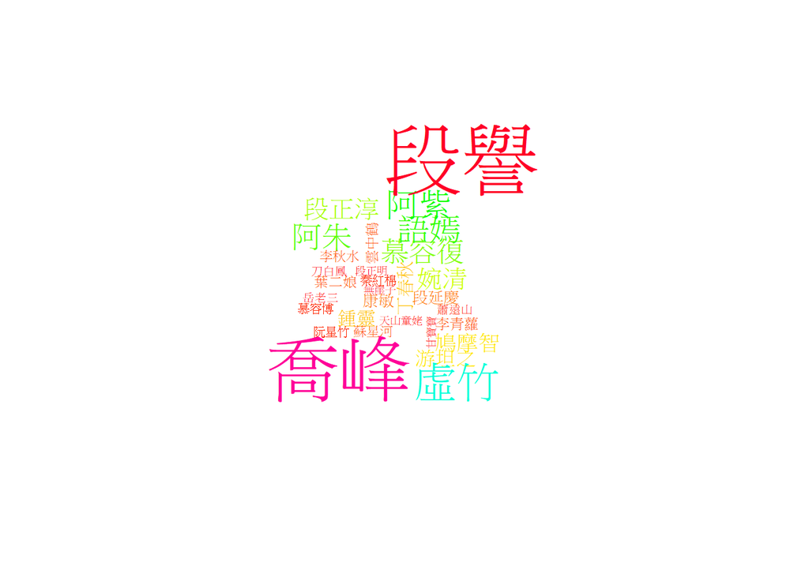

```r
wordcloud(names(y.row.sum),y.row.sum,scale=c(4,0.5),
          rot.per=0.1,min.freq=30,colors= rainbow(40))  #文字雲描素人物出現次數
```

# afterclass

```r
#installed.packages()
#install.packages("MASS")
```

```r
library(MASS)
str(crabs)
```

```
## 'data.frame':    200 obs. of  8 variables:
##  $ sp   : Factor w/ 2 levels "B","O": 1 1 1 1 1 1 1 1 1 1 ...
##  $ sex  : Factor w/ 2 levels "F","M": 2 2 2 2 2 2 2 2 2 2 ...
##  $ index: int  1 2 3 4 5 6 7 8 9 10 ...
##  $ FL   : num  8.1 8.8 9.2 9.6 9.8 10.8 11.1 11.6 11.8 11.8 ...
##  $ RW   : num  6.7 7.7 7.8 7.9 8 9 9.9 9.1 9.6 10.5 ...
##  $ CL   : num  16.1 18.1 19 20.1 20.3 23 23.8 24.5 24.2 25.2 ...
##  $ CW   : num  19 20.8 22.4 23.1 23 26.5 27.1 28.4 27.8 29.3 ...
##  $ BD   : num  7 7.4 7.7 8.2 8.2 9.8 9.8 10.4 9.7 10.3 ...
```

```r
head(crabs) #前六筆資料內容
```

```
##   sp sex index   FL  RW   CL   CW  BD
## 1  B   M     1  8.1 6.7 16.1 19.0 7.0
## 2  B   M     2  8.8 7.7 18.1 20.8 7.4
## 3  B   M     3  9.2 7.8 19.0 22.4 7.7
## 4  B   M     4  9.6 7.9 20.1 23.1 8.2
## 5  B   M     5  9.8 8.0 20.3 23.0 8.2
## 6  B   M     6 10.8 9.0 23.0 26.5 9.8
```

```r
#ch16_1
state.popu <- state.x77[,1]#取得人口數資料
head(state.popu)#驗證人口資料
```

```
##    Alabama     Alaska    Arizona   Arkansas California   Colorado
##       3615        365       2212       2110      21198       2541
```

```r
names(state.popu) <- NULL #刪除向量元素名稱
head(state.popu)#驗證結果
```

```
## [1]  3615   365  2212  2110 21198  2541
```

```r
#ch16_2
stateUSA <- data.frame(state.name, state.popu, state.area, state.region)#建立數據框
head(stateUSA)
```

```
##   state.name state.popu state.area state.region
## 1    Alabama       3615      51609        South
## 2     Alaska        365     589757         West
## 3    Arizona       2212     113909         West
## 4   Arkansas       2110      53104        South
## 5 California      21198     158693         West
## 6   Colorado       2541     104247         West
```

```r
#ch16_3
names(stateUSA)<- c("name","popu","area","region")#簡化名稱
head(stateUSA)
```

```
##         name  popu   area region
## 1    Alabama  3615  51609  South
## 2     Alaska   365 589757   West
## 3    Arizona  2212 113909   West
## 4   Arkansas  2110  53104  South
## 5 California 21198 158693   West
## 6   Colorado  2541 104247   West
```

```r
str(stateUSA)
```

```
## 'data.frame':    50 obs. of  4 variables:
##  $ name  : chr  "Alabama" "Alaska" "Arizona" "Arkansas" ...
##  $ popu  : num  3615 365 2212 2110 21198 ...
##  $ area  : num  51609 589757 113909 53104 158693 ...
##  $ region: Factor w/ 4 levels "Northeast","South",..: 2 4 4 2 4 4 1 2 2 2 ...
```

```r
#ch16_4
mycar <- mtcars[c(1,2,9,10)]#建立mycars物件，包含原mtcars物件4個欄位,mpg:英里,cyl:汽缸數,am:自排或手排,gear:擋位數
head(mycar)
```

```
##                    mpg cyl am gear
## Mazda RX4         21.0   6  1    4
## Mazda RX4 Wag     21.0   6  1    4
## Datsun 710        22.8   4  1    4
## Hornet 4 Drive    21.4   6  0    3
## Hornet Sportabout 18.7   8  0    3
## Valiant           18.1   6  0    3
```

```r
#ch16_5
mycar$am <- factor(mycar$am, labels=c("Auto","Manual"))#am欄位改成因子，0表示自排，1表示手排
str(mycar)
```

```
## 'data.frame':    32 obs. of  4 variables:
##  $ mpg : num  21 21 22.8 21.4 18.7 18.1 14.3 24.4 22.8 19.2 ...
##  $ cyl : num  6 6 4 6 8 6 8 4 4 6 ...
##  $ am  : Factor w/ 2 levels "Auto","Manual": 2 2 2 1 1 1 1 1 1 1 ...
##  $ gear: num  4 4 4 3 3 3 3 4 4 4 ...
```

```r
head(mycar)
```

```
##                    mpg cyl     am gear
## Mazda RX4         21.0   6 Manual    4
## Mazda RX4 Wag     21.0   6 Manual    4
## Datsun 710        22.8   4 Manual    4
## Hornet 4 Drive    21.4   6   Auto    3
## Hornet Sportabout 18.7   8   Auto    3
## Valiant           18.1   6   Auto    3
```

```r
#ch16_6
sapply(mycar, function(x) length(unique(x)))
```

```
##  mpg  cyl   am gear
##   25    3    2    3
```

```r
#ch16_7
mean(crabs$CW) #螃蟹甲殼寬度平均
```

```
## [1] 36.4145
```

```r
#ch16_8
mean(mycar$mpg) #汽車平均耗油
```

```
## [1] 20.09062
```

```r
#ch16_9
mean(stateUSA$popu) #每州平均人口數
```

```
## [1] 4246.42
```

```r
x <- c(100, 7, 12, 6)
median(x)
```

```
## [1] 9.5
```

```r
x <- c(100, 7, 8, 9, 10)
median(x)
```

```
## [1] 9
```

```r
#ch16_10
mean(mycar$gear)
```

```
## [1] 3.6875
```

```r
median(mycar$gear)
```

```
## [1] 4
```

```r
#ch16_11
median(crabs$CW)
```

```
## [1] 36.8
```

```r
#ch16_12
median(stateUSA$popu)
```

```
## [1] 2838.5
```

```r
#ch16_13
sd(crabs$BD)
```

```
## [1] 3.424772
```

```r
#ch16_14
var(crabs$BD)
```

```
## [1] 11.72907
```

```r
#ch16_15
sd(mycar$mpg)
```

```
## [1] 6.026948
```

```r
#ch16_16
var(mycar$mpg)
```

```
## [1] 36.3241
```

- range():全距

```r
#ch16_17
range(crabs$CW)
```

```
## [1] 17.1 54.6
```

```r
#ch16_18
range(stateUSA$popu)
```

```
## [1]   365 21198
```

```r
#ch16_19
range(mycar$mpg)
```

```
## [1] 10.4 33.9
```

- 四分位數

```r
# 20 to 25
x <- c(1,3,5,11,23,33,66,99)
quantile(x)
```

```
##    0%   25%   50%   75%  100%
##  1.00  4.50 17.00 41.25 99.00
```

```r
#ch16_20
quantile(stateUSA$popu)
```

```
##      0%     25%     50%     75%    100%
##   365.0  1079.5  2838.5  4968.5 21198.0
```

```r
#ch16_21
quantile(crabs$CW)
```

```
##   0%  25%  50%  75% 100%
## 17.1 31.5 36.8 42.0 54.6
```

```r
#ch16_22
quantile(mycar$mpg)
```

```
##     0%    25%    50%    75%   100%
## 10.400 15.425 19.200 22.800 33.900
```

- 百分位數 quantile()

```r
#ch16_23
quantile(crabs$CW,probs=c(0.1, 0.9))
```

```
##   10%   90%
## 25.67 46.57
```

```r
#ch16_24
quantile(stateUSA$popu,probs=c(0.1,0.9))
```

```
##     10%     90%
##   632.3 10781.2
```

```r
#ch16_25
quantile(mycar$mpg,0.1)
```

```
##   10%
## 14.34
```

```r
#ch16_25
table(stateUSA$region)
```

```
##
##     Northeast         South North Central          West
##             9            16            12            13
```

```r
#ch16_27
table(crabs$sex)
```

```
##
##   F   M
## 100 100
```

```r
#ch16_28
table(mycar$am)
```

```
##
##   Auto Manual
##     19     13
```

```r
regioninfo <- table(stateUSA$region)
regioninfo
```

```
##
##     Northeast         South North Central          West
##             9            16            12            13
```

```r
class(regioninfo)
```

```
## [1] "table"
```

```r
#ch16_29
regioninfo / sum(regioninfo)
```

```
##
##     Northeast         South North Central          West
##          0.18          0.32          0.24          0.26
```

```r
#ch16_30
crabsinfo <- table(crabs$sex)
crabsinfo / sum(crabsinfo)
```

```
##
##   F   M
## 0.5 0.5
```

```r
#ch16_31
carinfo <- table(mycar$am)
carinfo / sum(carinfo)
```

```
##
##    Auto  Manual
## 0.59375 0.40625
```

- 眾數

```r
#ch16_32
index <- regioninfo == max(regioninfo)
index #列出index邏輯向量
```

```
##
##     Northeast         South North Central          West
##         FALSE          TRUE         FALSE         FALSE
```

```r
names(regioninfo[index])
```

```
## [1] "South"
```

```r
#ch16_32_1
index <- carinfo == max(carinfo)
index
```

```
##
##   Auto Manual
##   TRUE  FALSE
```

```r
names(carinfo)[index]
```

```
## [1] "Auto"
```

```r
#ch16_33
index <- crabsinfo == max(crabsinfo)
index
```

```
##
##    F    M
## TRUE TRUE
```

```r
names(crabsinfo[index])
```

```
## [1] "F" "M"
```

- which.max()

```r
#ch16_34
which.max(regioninfo)
```

```
## South
##     2
```

```r
#ch16_35
which.max(carinfo)
```

```
## Auto
##    1
```

```r
#ch16_36
which.max(crabsinfo)
```

```
## F
## 1
```

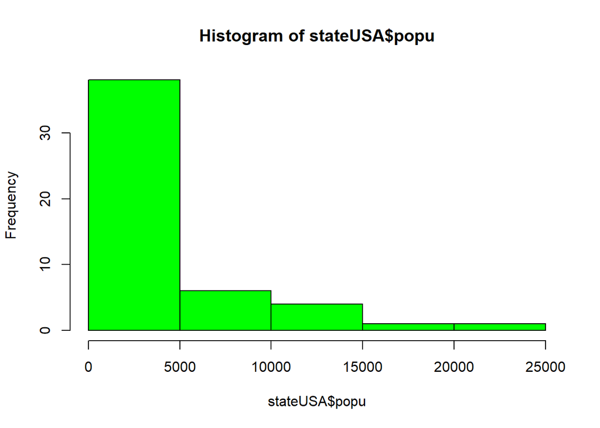

```r
#ch16_37
hist(stateUSA$popu, col="Green")
```

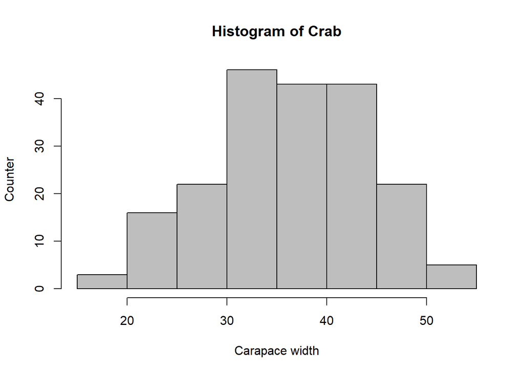

```r
#ch16_38
hist(crabs$CW, col="Gray", main="Histogram of Crab",
     xlab="Carapace width", ylab="Counter")
```

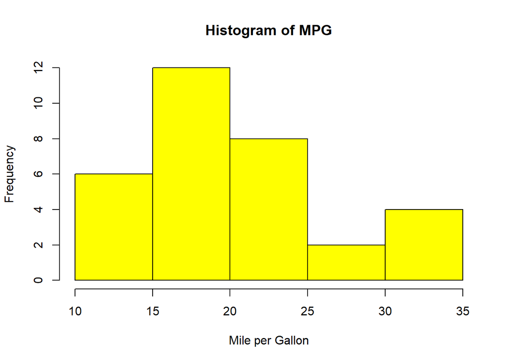

```r
#ch16_39
hist(mycar$mpg, col="Yellow", main="Histogram of MPG",
     xlab="Mile per Gallon")
```

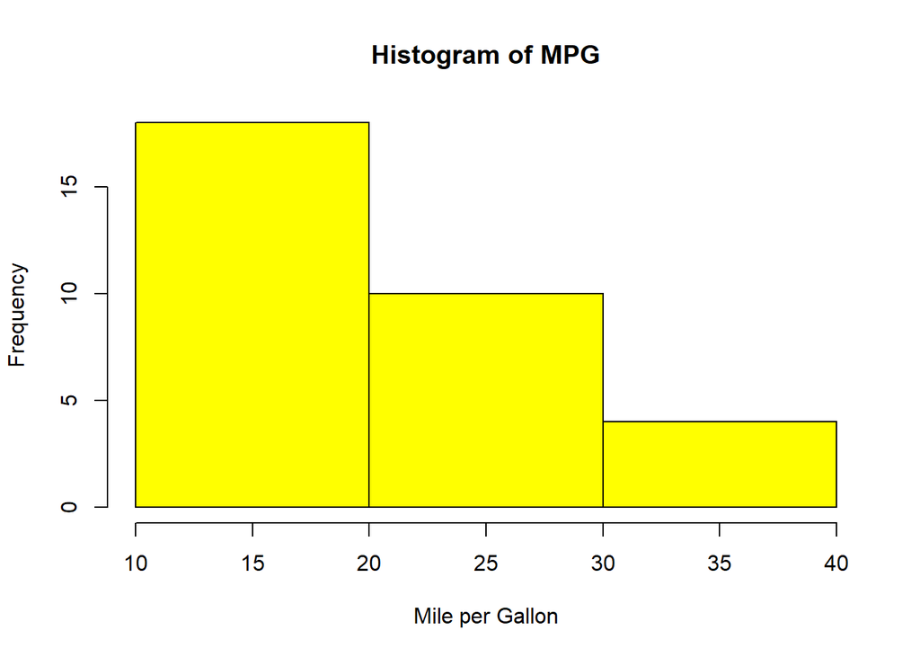

```r
#ch16_40
hist(mycar$mpg, col="Yellow", main="Histogram of MPG",
     xlab="Mile per Gallon", breaks=3) #breaks=3
```

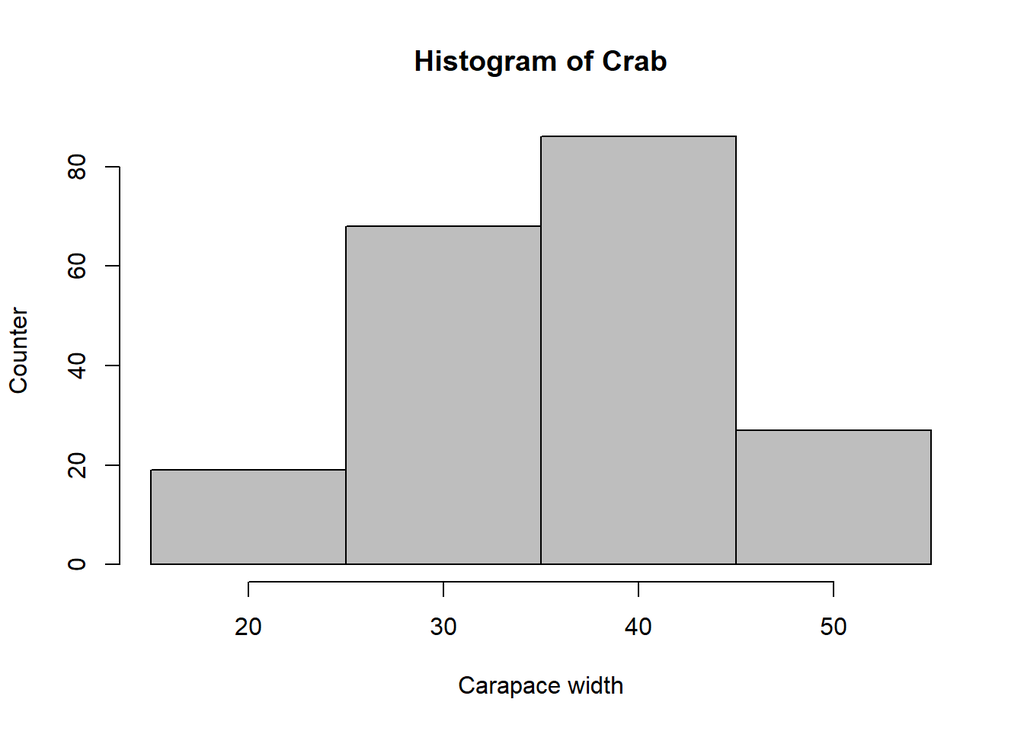

```r
#ch16_41
hist(crabs$CW, col="Gray", main="Histogram of Crab", xlab="Carapace width",
     ylab="Counter", breaks=c(15,25,35,45, 55)) #設定柱狀區間
```

```r
#ch16_42
dencrabs <- density(crabs$CW)#將物件轉成密度物件list
str(dencrabs)#驗證
```

```
## List of 7
##  $ x        : num [1:512] 9.77 9.87 9.97 10.07 10.18 ...
##  $ y        : num [1:512] 1.11e-05 1.27e-05 1.43e-05 1.63e-05 1.85e-05 ...
##  $ bw       : num 2.44
##  $ n        : int 200
##  $ call     : language density.default(x = crabs$CW)
##  $ data.name: chr "crabs$CW"
##  $ has.na   : logi FALSE
##  - attr(*, "class")= chr "density"
```

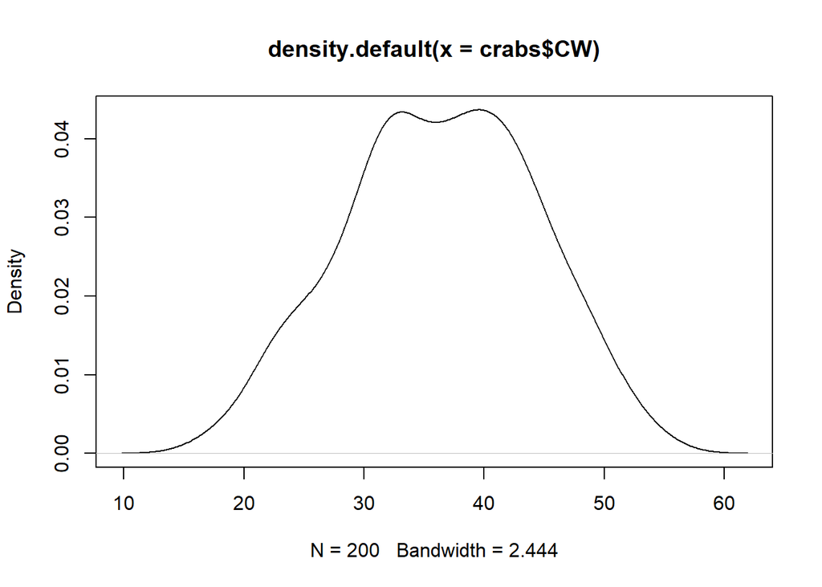

```r
plot(dencrabs)#繪製密度圖
```

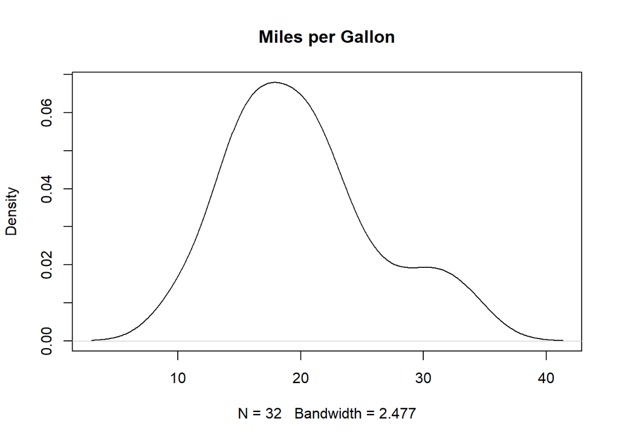

```r
#ch16_43
dencars <- density(mycar$mpg)
plot(dencars, main="Miles per Gallon")
```

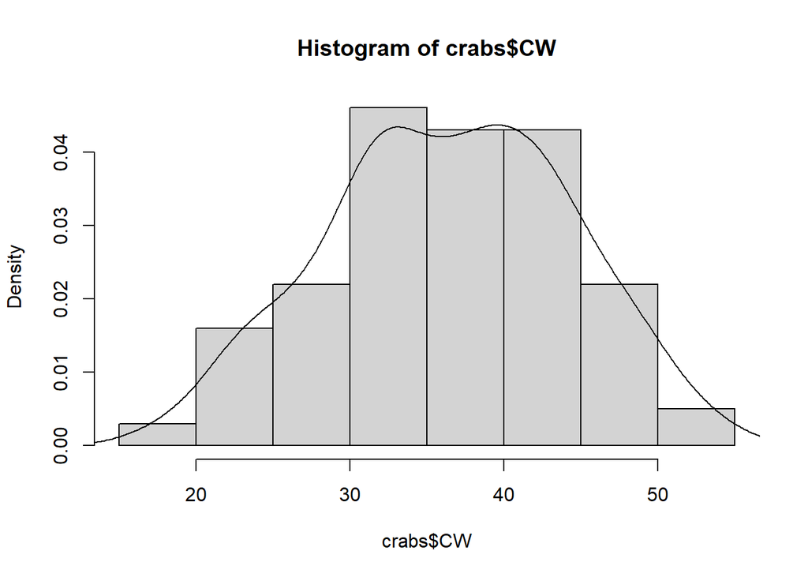

```r
#ch16_44
hist(crabs$CW, freq=FALSE)
dencrabs <- density(crabs$CW)
lines(dencrabs)
```

```r
#ch16_45
summary(mycar) #cyl,gear的最小值和第一四分位數相同，轉成因子(ch16_47)
```

```
##       mpg             cyl             am          gear
##  Min.   :10.40   Min.   :4.000   Auto  :19   Min.   :3.000
##  1st Qu.:15.43   1st Qu.:4.000   Manual:13   1st Qu.:3.000
##  Median :19.20   Median :6.000               Median :4.000
##  Mean   :20.09   Mean   :6.188               Mean   :3.688
##  3rd Qu.:22.80   3rd Qu.:8.000               3rd Qu.:4.000
##  Max.   :33.90   Max.   :8.000               Max.   :5.000
```

```r
#ch16_46
summary(stateUSA)
```

```
##      name                popu            area                  region
##  Length:50          Min.   :  365   Min.   :  1214   Northeast    : 9
##  Class :character   1st Qu.: 1080   1st Qu.: 37317   South        :16
##  Mode  :character   Median : 2838   Median : 56222   North Central:12
##                     Mean   : 4246   Mean   : 72368   West         :13
##                     3rd Qu.: 4968   3rd Qu.: 83234
##                     Max.   :21198   Max.   :589757
```

```r
#ch16_47
mycar$cyl <- as.factor(mycar$cyl) #將物件轉成因子
mycar$gear <- as.factor(mycar$gear)
summary(mycar)
```

```
##       mpg        cyl         am     gear
##  Min.   :10.40   4:11   Auto  :19   3:15
##  1st Qu.:15.43   6: 7   Manual:13   4:12
##  Median :19.20   8:14               5: 5
##  Mean   :20.09
##  3rd Qu.:22.80
##  Max.   :33.90
```

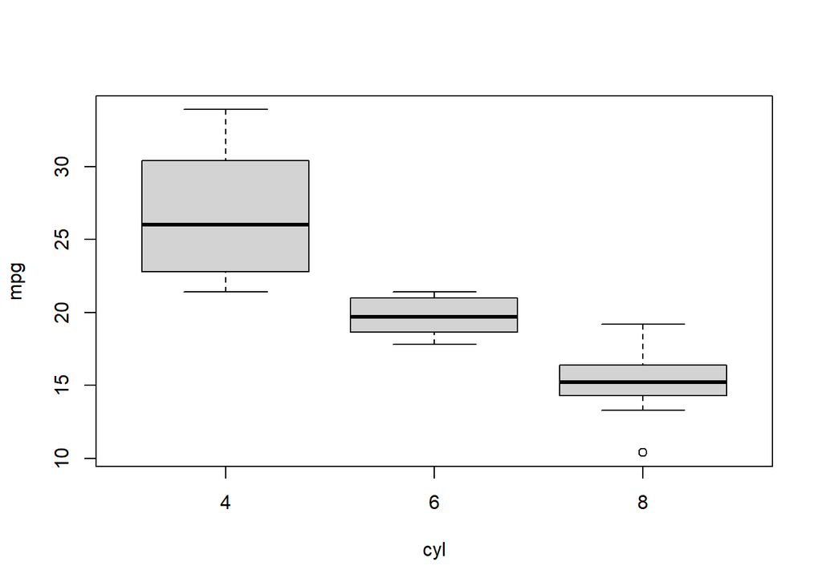

```r
#ch16_48
boxplot(mpg ~ cyl, data=mycar) #cyl對mpg之間的箱型圖
```

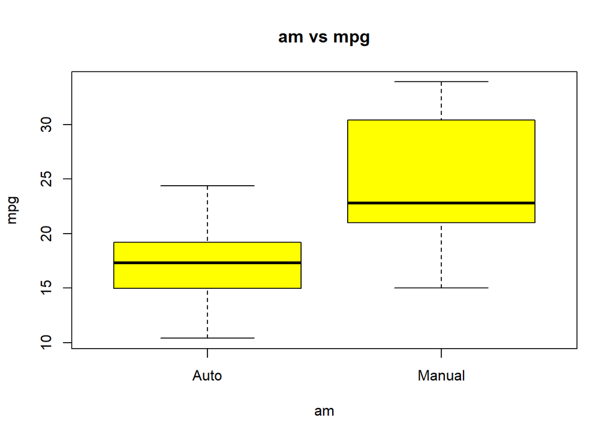

```r
#ch16_49
boxplot(mpg ~ am, data=mycar, main="am vs mpg", col="Yellow")
```

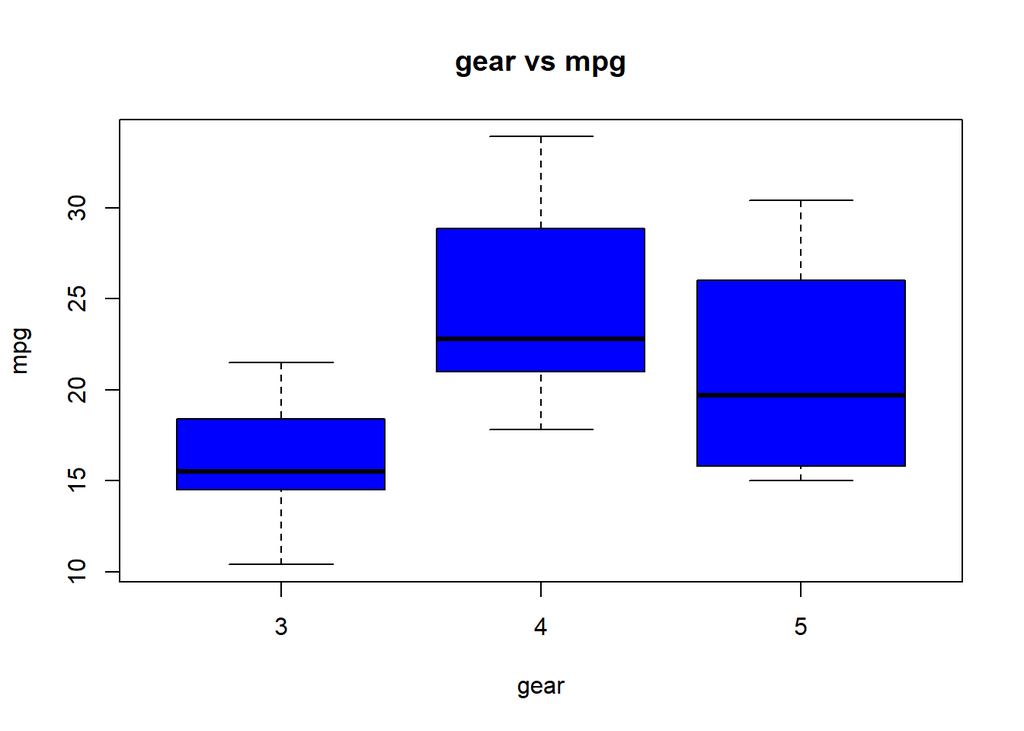

```r
#ch16_50
boxplot(mpg ~ gear, data=mycar, main="gear vs mpg", col="Blue")
```

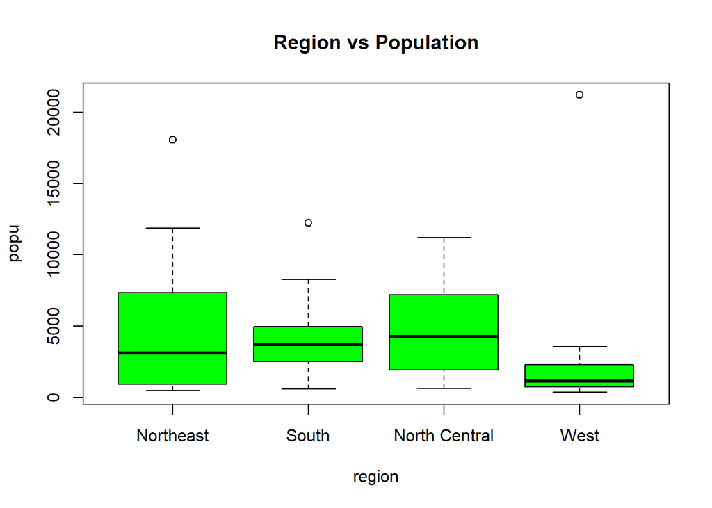

```r
#ch16_51
boxplot(popu ~ region, data=stateUSA,
        main="Region vs Population", col="Green")
```

```r
#空心圓點:線段的最大值 (空心圓點在線段下:最小值)
```

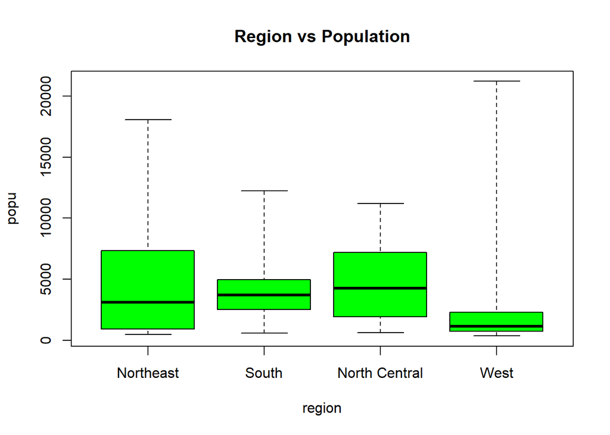

```r
#ch16_52
boxplot(popu ~ region, data=stateUSA,
        main="Region vs Population", col="Green", range=0)
```